# The Electron Scattering Code

Xingzhuo "Gesa" Chen

Here it is the example of the electron scattering radiative transfer calculation. I use pytorch for the calculation. To notice, the code was developed on the Grace cluster with a NVIDIA A100 GPU card, and the code will use about 15 GB of GPU memory. Please change some hyper-parameters if you don't have a A100. Moreover, the training time is about half an hour on a single A100 GPU node. All the physical units used in the code is in "cgs" (centimeter, unit, second) system if not clarified.

```python
import os
import torch as t
import numpy as np
from torch import nn
from torch.optim import Adam
from astropy import units as u
import matplotlib.pyplot as plt
from astropy import constants as c
from torch.autograd import Variable
```

## The Neural Network

Here it is the neural network. There are 10 layers, and the activation function is tanh.

```python
class Inten(nn.Module):
    def __init__(self):
        super(Inten, self).__init__()
        self.fc1=nn.Linear(4,128)
        self.fc2=nn.Linear(128,128)
        self.fc3=nn.Linear(128,128)
        self.fc4=nn.Linear(128,128)
        self.fc5=nn.Linear(128,128)
        self.fc6=nn.Linear(128,128)
        self.fc7=nn.Linear(128,128)
        self.fc8=nn.Linear(128,64)
        self.fc9=nn.Linear(64,32)
        self.fc10=nn.Linear(32,1)

    def forward(self,Xin):
        self.Xin=Xin
        out=nn.Tanh()(self.fc1(Xin))
        out=nn.Tanh()(self.fc2(out))
        out=nn.Tanh()(self.fc3(out))
        out=nn.Tanh()(self.fc4(out))
        out=nn.Tanh()(self.fc5(out))
        out=nn.Tanh()(self.fc6(out))
        out=nn.Tanh()(self.fc7(out))
        out=nn.Tanh()(self.fc8(out))
        out=nn.Tanh()(self.fc9(out))

        out=self.fc10(out)
        return out
```

```python
IntenNet=Inten().double().cuda()
```

## Parameter Initialization

pytorch uses "xavier" initialization to initialize the neural network parameters by default (if I remember it correctly), I perfer to use "kaiming" initialization. Sometimes "xavier" initialization may lead the nerual network to return same value even with different input, and the training process get stuck in a saddle point for a long time.

```python
for i in IntenNet.parameters():
    if len(i.shape)<2:continue
    nn.init.kaiming_uniform_(i)
```

## Optimizer

I use Adam to update the parameters. I manually modify the learning rate from 0.003, 0.001, 0.0005, to 0.0002. If the loss function is not decreasing for 1 or 2 epochs, I will lower the learning rate.

```python
optim=Adam(IntenNet.parameters(),lr=0.0002,betas=(0.5,0.999))
```

## The Collocation Points

collBatch is the number of collocation points in a batch.

initBatch is the number of points sampled for the initial condition.

batchNum is the number of batches.

epochNum is the number of epoches.

Please lower the collBatch value and the initBatch value if the GPU memory is limited.

By the way, I didn't finish a full 2000 epoch training at all, I lost my patience after 50 epochs.

```python
collBatch=3500
initBatch=3500
batchNum=300
epochNum=2000
```

## The Physical Parameters

sigmaT is the cross section of electron, in the unit of cm^2.

N is the number of electron per cubic cemtermeter.

sig is the scattering coefficient $\sigma$ used in the radiative transfer equation.

cli is the speed of light in the unit of cm/s.

zmax is the upper boundary of the radiation field we will calculate.

zmin is the lower boundary of the radiation field.

tmax is the maximum time in second.

```python
sigmaT=c.sigma_T.to('cm^2').value #thompson cross section in cm^2
N=1e-10*6.02*10**23 #Number of electron per cm^3.
sig=sigmaT*N
cli=c.c.to('cm/s').value #speed of light in meter/second
zmax=1*cli
zmin=-1*cli
tmax=1
```

## The Random Sampler

The points are randomly sampled in the parameter space, and split into batches. There are points for the collocation points and the initial condition points.

```python
ztptOrig=np.random.random(collBatch*batchNum*4).reshape(-1,4)
ztptOrig=ztptOrig*np.array([1,np.pi*2,np.pi,1])+np.array([0,0,0,0])
ztptOrig=t.tensor(ztptOrig).cuda()
ztptOrig=ztptOrig.split(collBatch)
ztptOrig=[i for i in ztptOrig]

ztptInitOrig=np.random.random(initBatch*batchNum*4).reshape(-1,4)
ztptInitOrig=ztptInitOrig*np.array([1,np.pi*2,np.pi,0])+np.array([0,0,0,0])
ztptInitOrig=t.tensor(ztptInitOrig).cuda()
ztptInitOrig=ztptInitOrig.split(initBatch)
ztptInitOrig=[i for i in ztptInitOrig]
```

## The Training

### The physical system

We will calculate a system with electron scattering effect.

We use plane parallel approximation, the system is an infinitely large slab, and the thickness is 2 light-seconds. We consider the spatial coordinate z, zenith coordinate phi ($\varphi$), azimuth coordinate theta ($\theta$), time for the radiation field. The center of the slab is set as z=0, so the boundaries of the slab are z=-1 light-second and z=1 light-second, which are defined in zmax and zmin before.

Electron density is N (as is defined above) inside the slab and 0 outside the slab. Finally, between z=-0.1 and z=0.1 light-second, the emission is $f=10^{-10}$ (In the equation 1 of Mishra's PINN paper, this paremeter is defined as f, but some other papers define it as j).

The initial condition is radiation field being zero.

### The electron scattering phase function

The phase function ($\Phi$) describes the probability of receiving a scattered photon per solid angle at a given scattered angle for the scatter event. The electron scattering phase function is:

$\Phi(\phi_{bt})=\frac{1+cos^2(\phi_{bt})}{2}\times \frac{3}{2}\times \frac{1}{4\pi}$,

where $\phi_{bt}$ is the angle between the input photon and the output photon. This scattering equation satisfies:

$\int_{sphere}\Phi(\phi_{bt}) d\Omega=1$.

The above equation can also be written as:

$\int_{0}^{2\pi}d\theta \int_{0}^{\pi}d\varphi\ \Phi(\phi_{bt})sin(\varphi)=1$.

### The radiative transfer equation

The radiative transfer equation used in this code is:

$\frac{d I}{dt}+cos(\varphi)\frac{dI}{dz}+\sigma I-\sigma \int_{sphere} \Phi(\phi_{bt})I(\Omega_{in})d\Omega_{in}-f=0$

The spatial gradient term is $cos(\varphi)\frac{dI}{dz}$, because x and y coordinates are not considered.

### The code

I set marks which look like #(1) , at the end of the lines. The following items are the notes for the marked lines.

1. When calculating the integration term in the radiative transfer equation, I set 20 by 20 grids, as is defined in thetaIntStep and phiIntStep.
2. The input of the neural network is z, theta, phi, t (ztpt). theta and phi is in (0,2pi) and (0,pi), z and t are rescaled into (0,1), so their gradients $\frac{dI}{dz}$ and $\frac{dI}{dt}$ are scaled back.
3. This chunk of code specifies the grid points of the integration term in the radiative transfer equation. (thetaIn, phiIn) is the inflow direction.
4. cosBetween calculates the cosine angle between the inflow direction and the outflow direction, and will be used in the integration term.

$cos(\phi_{bt})=sin(\theta_{in})sin(\varphi_{in})sin(\theta_{out})sin(\phi_{out})+cos(\theta_{in})sin(\phi_{in})cos(\theta_{out})sin(\phi_{out})+cos(\phi_{in})cos(\phi_{out})$

1. I notice using a "detach" here can significantly reduce the GPU memory requirement of the code. Possibly this step disables the gradient propogation in the integration term.
2. jFreq here is the emission term in the radiative transfer equation, also known as "f" term.
3. The radiative transfer equation.
4. I designed a markov-chain-monte-carlo method to update the collocation points, and this method will be used every 4 epochs. This method samples a new batch of collocation points in the parameter space, then compare the errors between the previous collocation points and the new collocation points, one by one. If the error for the new collocation point is larger, then this collocation points will be updated. If the error for the new collocation point is smaller, the probability of updating the collocation point will be $\frac{error_{new}}{error_{old}}$. The error here will be the square of the radiative transfer equation residual. The sum of errors will be the loss.  
   This method works well on another radiative transfer toy model, and successfully put more collocation points at the regions which I thoult will be more important for the PDE solution. The result is as good as self-adaptive weights as far as I can see. However, the weight balance between the PDE loss and the initial condition loss is not considered in this method.
5. I multiply the PDE loss by $10^{20}$, and multiply the initial condition loss by 30, them sum them together to form the final loss function. The loss of the final step is shown in the output of the cell.

```python
thetaIntStep=20# (1)
phiIntStep=20
thetaPhiInStep=thetaIntStep*phiIntStep
for epoch in range(epochNum):
    for batch in range(batchNum):

        ztpt=Variable(ztptOrig[batch].clone().detach(),requires_grad=True)
        IntenNet.zero_grad()
        IntenOut=IntenNet(ztpt).flatten()
        XinGrad=t.autograd.grad(t.sum(IntenOut),ztpt,retain_graph=True,create_graph=True)[0]
        XinGrad[:,0]=XinGrad[:,0]/(zmax-zmin) #(2)
        XinGrad[:,3]=XinGrad[:,3]/tmax

        thetaIn=np.linspace(0,2*np.pi,num=thetaIntStep)#(3)
        phiIn=np.linspace(0,np.pi,num=phiIntStep)
        thetaIn,phiIn=np.meshgrid(thetaIn,phiIn)
        thetaIn,phiIn=t.tensor(thetaIn).flatten().cuda(),t.tensor(phiIn).flatten().cuda()
        thetaInbig,zbig=t.meshgrid(thetaIn,ztpt[:,0])
        phiInbig,tbig=t.meshgrid(phiIn,ztpt[:,3])
        ztptBig=t.vstack([zbig.flatten(),thetaInbig.flatten(),phiInbig.flatten(),tbig.flatten()]).T

        IntenBig=IntenNet(ztptBig).flatten().reshape([thetaPhiInStep,-1])
        IntenBig=IntenBig.clone().detach()
        cosBetween=t.sin(thetaInbig)*t.sin(phiInbig)*t.sin(ztpt[:,1])*t.sin(ztpt[:,2])+t.cos(thetaInbig)*t.sin(phiInbig)*t.cos(ztpt[:,1])*t.sin(ztpt[:,2])+t.cos(phiInbig)*t.cos(ztpt[:,2])#(4)
        cosBetween=cosBetween.clone().detach()
        IntegSum=t.sum((1+cosBetween**2)/2*t.sin(phiInbig)*IntenBig,axis=0)/thetaPhiInStep*2*np.pi**2*1.5/4/np.pi
        IntegSum=IntegSum.clone().detach()#(5)
        jFreq=(t.abs(ztpt[:,0]-0.5)<0.05)*1e-10#(6)

        lossEqu=XinGrad[:,3]/cli+t.cos(ztpt[:,2])*XinGrad[:,0]-jFreq+sig*IntenOut-sig*IntegSum#(7)
        lossEqu=lossEqu**2
        curLosLis=lossEqu.clone().detach()


        if epoch%4!=0:#(8)


            lossEqu=t.sum(lossEqu)*1e20#(9)

            ztptInit=Variable(ztptInitOrig[batch].clone().detach(),requires_grad=True)
            IntenOutInit=IntenNet(ztptInit).flatten()
            lossInit=(IntenOutInit-0)**2
            lossInit=t.sum(lossInit)*30

            loss=lossEqu+lossInit
            if batch%20==0:
                print(loss.item(),lossEqu.item(),lossInit.item())
            loss.backward()
            optim.step()






        if epoch%4==0:
            IntenNet.zero_grad()
            ztpt=np.random.random(collBatch*4).reshape(-1,4)
            ztpt=ztpt*np.array([1,np.pi*2,np.pi,1])+np.array([0,0,0,0])
            ztpt=t.tensor(ztpt).cuda()
            ztpt=Variable(ztpt,requires_grad=True)
            ztptNew=ztpt.clone().detach()

            IntenOut=IntenNet(ztpt).flatten()
            XinGrad=t.autograd.grad(t.sum(IntenOut),ztpt,retain_graph=True,create_graph=True)[0]
            XinGrad[:,0]=XinGrad[:,0]/(zmax-zmin)
            XinGrad[:,3]=XinGrad[:,3]/tmax

            thetaIn=np.linspace(0,2*np.pi,num=thetaIntStep)
            phiIn=np.linspace(0,np.pi,num=phiIntStep)
            thetaIn,phiIn=np.meshgrid(thetaIn,phiIn)
            thetaIn,phiIn=t.tensor(thetaIn).flatten().cuda(),t.tensor(phiIn).flatten().cuda()
            thetaInbig,zbig=t.meshgrid(thetaIn,ztpt[:,0])
            phiInbig,tbig=t.meshgrid(phiIn,ztpt[:,3])
            ztptBig=t.vstack([zbig.flatten(),thetaInbig.flatten(),phiInbig.flatten(),tbig.flatten()]).T

            IntenBig=IntenNet(ztptBig).flatten().reshape([thetaPhiInStep,-1])
            IntenBig=IntenBig.clone().detach()
            cosBetween=t.sin(thetaInbig)*t.sin(phiInbig)*t.sin(ztpt[:,1])*t.sin(ztpt[:,2])+t.cos(thetaInbig)*t.sin(phiInbig)*t.cos(ztpt[:,1])*t.sin(ztpt[:,2])+t.cos(phiInbig)*t.cos(ztpt[:,2])
            cosBetween=cosBetween.clone().detach()
            IntegSum=t.sum((1+cosBetween**2)/2*t.sin(phiInbig)*IntenBig,axis=0)/thetaPhiInStep*2*np.pi**2*1.5/4/np.pi
            IntegSum=IntegSum.clone().detach()
            jFreq=(t.abs(ztpt[:,0]-0.5)<0.05)*1e-10

            lossEqu=XinGrad[:,3]/cli+t.cos(ztpt[:,2])*XinGrad[:,0]-jFreq+sig*IntenOut-sig*IntegSum
            lossEqu=lossEqu**2
            nexLosLis=lossEqu.clone().detach()
            uniRand=t.tensor(np.random.random(len(ztpt))).cuda()
            ztptUpd=ztptOrig[batch].clone().detach()
            mask=(nexLosLis/curLosLis>uniRand)
            mask=mask.detach().cpu().numpy()
            ztptUpd[mask]=ztptNew[mask]
            ztptOrig[batch]=ztptUpd

    print('epoch '+str(epoch))
    #break
```

```
epoch 0
77.00035212427214 76.8121258485972 0.18822627567492972
48.335538053464 48.123229411583424 0.21230864188057874
31.62893701064067 31.520234869190578 0.10870214145009213
37.69958616883504 37.55723348702167 0.14235268181337316
46.26269940405301 46.152311282408284 0.11038812164472395
50.60618000822248 50.171336578365676 0.4348434298568068
34.056042444232965 33.954127270077265 0.1019151741557026
29.966008411530076 29.889872942607173 0.07613546892290424
34.874005699427045 34.48764214734095 0.3863635520860969
28.6799148796842 28.407519612232893 0.2723952674513099
53.77135321665802 53.68695486098321 0.084398355674815
31.213214715482 31.060011638126603 0.15320307735539557
32.44596037693139 32.36877399250056 0.07718638443083237
36.13493563127462 36.01651157681274 0.11842405446188611
34.275169333438654 34.06157391063115 0.21359542280751123
epoch 1
35.585519428547435 35.318080965640746 0.2674384629066874
44.82198145248283 44.69374876319476 0.12823268928807202
28.39489532712516 28.258588548500068 0.13630677862509025
41.19115312126952 40.97878845493909 0.2123646663304287
41.8572860046027 41.74566266893071 0.11162333567198633
45.00792181980468 44.68228360226107 0.3256382175436086
34.54099349166649 34.46105797617717 0.07993551548931446
27.21244610942252 27.13748233506868 0.07496377435384101
32.424648470468824 32.12757631278615 0.297072157682678
25.97969924585904 25.62103957416287 0.35865967169617147
48.24246461409305 48.16228519389251 0.08017942020054127
29.87619444745758 29.786306729225807 0.08988771823177188
30.823032315906975 30.683922148349442 0.1391101675575334
34.264271283961584 34.11135884906995 0.15291243489163092
31.82400964190514 31.622123915421227 0.20188572648391073
epoch 2
32.95966731322188 32.745652194187144 0.21401511903473694
38.734318629108365 38.61949058016061 0.11482804894775947
31.475393198055727 31.33306443064764 0.1423287674080875
40.30291750844166 40.12075908238134 0.1821584260603209
41.487002691868895 41.376548183093405 0.11045450877549004
40.51005846532507 40.20554651976615 0.30451194555892386
33.03366165786712 32.94907285806567 0.08458879980145223
```

[output cut: 91 more lines]

```
31.608444554841913 31.44456320511693 0.16388134972498455
65.86696976769682 65.68840483358213 0.17856493411469085
31.845923906180424 31.472228011633202 0.373695894547223
45.11825921347422 44.74756589522327 0.370693318250947
34.35785384308471 34.106333310203524 0.25152053288118453
33.760346781847744 33.65013994776567 0.11020683408206902
37.04670664438879 36.97983731085605 0.06686933353274027
30.288896260520797 30.168453659276032 0.12044260124476636
31.11274435406221 30.81854543606534 0.2941989179968719
28.377925786749568 28.232262134515974 0.14566365223359368
27.31982165494479 27.067326124386863 0.25249553055792767
43.00038778563945 42.89706012173362 0.10332766390583284
29.12889406545948 28.861118590719983 0.2677754747394972
28.277399563610693 28.041425795688127 0.23597376792256686
39.01282728281553 38.88013382379327 0.13269345902225657
```

[output not shown]

## The Result

### Light Propagation 1

This figure shows the radiation intensity from z=0.1 to z=1, at the direction $\varphi=0$. The radiation intensity is mainly dependent on the unscattered light directly from the source. With the increase of distance, more light get scattered and the radiation intensity decreases. To notice, the speed of light measured from the radiation field can be slightly larger than the true speed of light. For example, at the coordinate z=1 light-second, the distance to the emission region is at least 0.9 light-second, so there should be zero radiation intensity until t=0.9 second. However, the radiation intensity at z=1 light-second starts to increase at t=0.8.

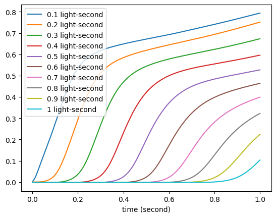

```python
plt.style.use('default')
ztpt=t.tensor(np.zeros([200,4]))
ztpt=ztpt.cuda()
for zloc in [0.55,0.6,0.65,0.7,0.75,0.8,0.85,0.9,0.95,1]:
    ztpt[:,0]=zloc
    ztpt[:,2]=np.pi*0.0
    ztpt[:,3]=t.tensor(np.linspace(0,1,num=200)).float().cuda()
    plt.plot(np.linspace(0,1,num=200),IntenNet(ztpt).cpu().detach().numpy(),label=str(round(zloc*2-1,3))+' light-second')
plt.legend()
plt.xlabel('time (second)')
```

### The Mirror Symmetry

As the material is symmetric, we expect the radiation field is also symmetric. Here it is the radiation field from z=-0.1 light-second to z=-1 light-second, at the direction $\varphi=\pi$. The radiation intensity is similar to the above one.

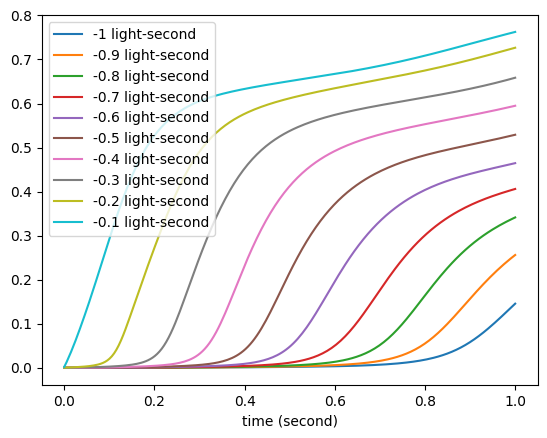

```python
plt.style.use('default')
ztpt=t.tensor(np.zeros([200,4]))
ztpt=ztpt.cuda()
for zloc in [0,0.05,0.1,0.15,0.2,0.25,0.3,0.35,0.4,0.45]:
    ztpt[:,0]=zloc
    ztpt[:,2]=np.pi*1
    ztpt[:,3]=t.tensor(np.linspace(0,1,num=200)).float().cuda()
    plt.plot(np.linspace(0,1,num=200),IntenNet(ztpt).cpu().detach().numpy(),label=str(round(zloc*2-1,3))+' light-second')
plt.legend()
plt.xlabel('time (second)')
```

### The Scattered Light

When the viewing angle is $\varphi=0.5\pi$, the emitted light between $z=-0.1$ and $z=0.1$ cannot directly reach to the viewer without scattering. In the figure below, the scattered light can be observed at different z coordinates.

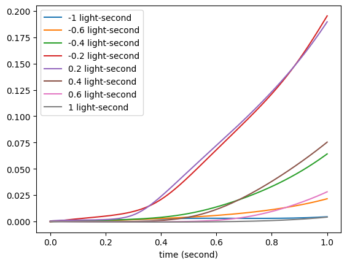

```python
plt.style.use('default')
ztpt=t.tensor(np.zeros([200,4]))
ztpt=ztpt.cuda()
for zloc in [0,0.2,0.3,0.4,0.6,0.7,0.8,1]:
    ztpt[:,0]=zloc
    ztpt[:,2]=np.pi*0.5
    ztpt[:,3]=t.tensor(np.linspace(0,1,num=200)).float().cuda()
    plt.plot(np.linspace(0,1,num=200),IntenNet(ztpt).cpu().detach().numpy(),label=str(round(zloc*2-1,3))+' light-second')
plt.legend()
plt.xlabel('time (second)')
```

### Rotational Conservation

Because the scattering phase function is only dependent on the zenith angle ($\phi_{bt}$), and the system is based on plane parallel approximation, the radiation field should not change under the different $\theta$ value. The predicted radiation intensity is slightly changing with $\theta$ angle.

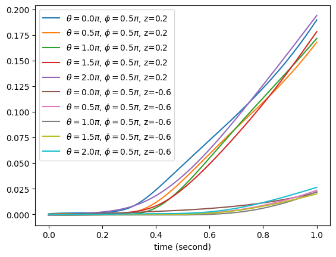

```python
plt.style.use('default')
ztpt=t.tensor(np.zeros([200,4]))
ztpt=ztpt.cuda()
for theta in [0,0.5*np.pi,np.pi,1.5*np.pi,2*np.pi]:
    ztpt[:,0]=0.6
    ztpt[:,1]=theta
    ztpt[:,2]=np.pi*0.5
    ztpt[:,3]=t.tensor(np.linspace(0,1,num=200)).float().cuda()
    plt.plot(np.linspace(0,1,num=200),IntenNet(ztpt).cpu().detach().numpy(),label=r'$\theta=$'+str(round(theta/np.pi,3))+r'$\pi$, $\phi=0.5\pi$, z=0.2')
for theta in [0,0.5*np.pi,np.pi,1.5*np.pi,2*np.pi]:
    ztpt[:,0]=0.2
    ztpt[:,1]=theta
    ztpt[:,2]=np.pi*0.5
    ztpt[:,3]=t.tensor(np.linspace(0,1,num=200)).float().cuda()
    plt.plot(np.linspace(0,1,num=200),IntenNet(ztpt).cpu().detach().numpy(),label=r'$\theta=$'+str(round(theta/np.pi,3))+r'$\pi$, $\phi=0.5\pi$, z=-0.6')
plt.legend()
plt.xlabel('time (second)')
```

### Inside the Emission Field

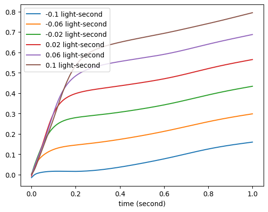

```python
plt.style.use('default')
ztpt=t.tensor(np.zeros([200,4]))
ztpt=ztpt.cuda()
for zloc in [0.45,0.47,0.49,0.51,0.53,0.55]:
    ztpt[:,0]=zloc
    ztpt[:,2]=np.pi*0.0
    ztpt[:,3]=t.tensor(np.linspace(0,1,num=200)).float().cuda()
    plt.plot(np.linspace(0,1,num=200),IntenNet(ztpt).cpu().detach().numpy(),label=str(round(zloc*2-1,3))+' light-second')
plt.legend()
plt.xlabel('time (second)')
```

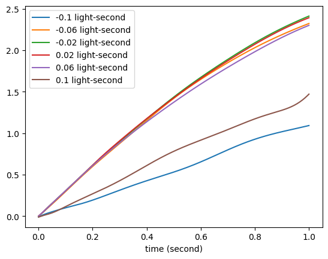

```python
plt.style.use('default')
ztpt=t.tensor(np.zeros([200,4]))
ztpt=ztpt.cuda()
for zloc in [0.45,0.47,0.49,0.51,0.53,0.55]:
    ztpt[:,0]=zloc
    ztpt[:,2]=np.pi*0.5
    ztpt[:,3]=t.tensor(np.linspace(0,1,num=200)).float().cuda()
    plt.plot(np.linspace(0,1,num=200),IntenNet(ztpt).cpu().detach().numpy(),label=str(round(zloc*2-1,3))+' light-second')
plt.legend()
plt.xlabel('time (second)')
```

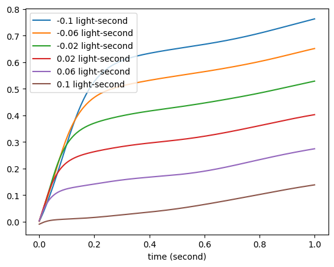

```python
plt.style.use('default')
ztpt=t.tensor(np.zeros([200,4]))
ztpt=ztpt.cuda()
for zloc in [0.45,0.47,0.49,0.51,0.53,0.55]:
    ztpt[:,0]=zloc
    ztpt[:,2]=np.pi*1
    ztpt[:,3]=t.tensor(np.linspace(0,1,num=200)).float().cuda()
    plt.plot(np.linspace(0,1,num=200),IntenNet(ztpt).cpu().detach().numpy(),label=str(round(zloc*2-1,3))+' light-second')
plt.legend()
plt.xlabel('time (second)')
```

```python
t.save(IntenNet.state_dict(),'ExampleSource.to')
```